# R Code & Statisitcs Work Sample

Graduate School Class Final Project

Allyson Fierro

March 2018

```r
library(knitr)
library(plyr)
library(dplyr)
```

```r
library(ggplot2)
options(scipen = 4)
```

```r
nlsy.1 <- read.csv("http://www.andrew.cmu.edu/user/achoulde/94842/final_project/nlsy79/nlsy79_income.csv", header=TRUE)

colnames(nlsy.1) <- c("VERSION_R25_2012",
    "CASEID_1979",
    "FAM-2A_1979",
    "FAM-POB_1979",
    "forgn.lang",
    "FAM-3A_1979",
    "FAM-RES_1979",
    "FAM-6_1979",
    "R_REL-1_COL_1979",
    "SCHOOL-31_1979",
    "MIL-6_1979",
    "WOMENS-ROLES_000001_1979",
    "WOMENS-ROLES_000002_1979",
    "WOMENS-ROLES_000003_1979",
    "WOMENS-ROLES_000004_1979",
    "WOMENS-ROLES_000006_1979",
    "WOMENS-ROLES_000007_1979",
    "WOMENS-ROLES_000008_1979",
    "EXP-OCC_1979",
    "EXP-9_1979",
    "race",
    "sex",
    "MARSTAT-KEY_1979",
    "FAMSIZE_1979",
    "pov.stat.1979",
    "POLICE-1_1980",
    "POLIC-1C_1980",
    "POLICE-2_1980",
    "ALCH-2_1983",
    "DS-8_1984",
    "DS-9_1984",
    "Q13-5_TRUNC_REVISED_1990",
    "POVSTATUS_1990",
    "HGCREV90_1990",
    "jobs.num",
    "NUMCH90_1990",
    "AGEYCH90_1990",
    "DS-12_1998",
    "DS-13_1998",
    "INDALL-EMP.01_2000",
    "CPSOCC80.01_2000",
    "OCCSP-55I_CODE_2000",
    "Q2-15B_2000",
    "Q10-2_2000",
    "Q13-5_TRUNC_REVISED_2000",
    "FAMSIZE_2000",
    "TNFI_TRUNC_2000",
    "POVSTATUS_2000",
    "MARSTAT-COL_2000",
    "mar.stat.2000",
    "MO1M1B_XRND",
    "Q2-10B~Y_2012",
    "INDALL-EMP.01_2012",
    "OCCALL-EMP.01_2012",
    "OCCSP-55I_CODE_2012",
    "Q2-15A_2012",
    "Q12-6_2012",
    "income",
    "Q13-5_SR000001_2012",
    "Q13-5_SR000002_2012",
    "Q13-18_TRUNC_2012",
    "Q13-18_SR000001_TRUNC_2012",
    "fam.size",
    "REGION_2012",
    "edu.attmnt",
    "urban.rural.2012",
    "JOBSNUM_2012")
```

**Data Summary**

*Overview of the Data*

The National Longitudinal Survey of Youth, 1979 surveyed youth ages 14-22. There 12,686 respondents in this survey and they were first surveyed in 1979 and then annually through 1994. Surveys after that point occurred biennially.

With this survey data, we will try to answer the questions, “Is there a significant difference in income between men and women? Does the difference vary depending on other factors?”

In addition to the income and sex variables, I chose to observe if the difference in income is also present in variables indicating highest grade completed, race, if a foreign language was spoken in their home as a child, poverty status in 1979, marital status in 2000 and family size in 2012.

*Income Values*

Before I created any summary tables or visualizations, I looked into the income variable in the data. Running the QQ plot below, I could see that the income variable is not normally distributed. The respondent’s in the top 2% of earners are top coded. This is skewing the data. As you can see, the top earners are making the end tail heavier.

```r
#subset Data
nlsy.2 <- nlsy.1[, c(5, 21, 22, 25, 50, 58, 63, 65)]

#Make education continuous
#Creating new variable
nlsy.2$edu.new <- NA
nlsy.2$edu.new <- as.numeric(nlsy.2$edu.attmnt)

#Map values
nlsy <- mutate(nlsy.2,
               forgn.lang = as.factor(mapvalues(forgn.lang,
                            from = c(1, 0, -3),
                            to = c("Yes", "No", NA))),
               race = as.factor(mapvalues(race,
                            from = c(1, 2, 3),
                            to = c("Latino", "Black", "White"))),
               sex = as.factor(mapvalues(sex,
                            from = c(1,2),
                            to = c("Male", "Female"))),
               pov.stat.1979 = as.factor(mapvalues(pov.stat.1979,
                            from = c(1, 0, -3),
                            to = c("In Poverty" , "Not in Poverty", NA))),
               mar.stat.2000 = as.factor(mapvalues(mar.stat.2000,
                            from = c(0, 1, 6, -3, -5),
                            to = c("Never Married", "Married", "Widowed", NA, NA))),
               mar.stat.2000 = as.factor(mapvalues(mar.stat.2000,
                            from = c(2, 3),
                            to = rep("Separated or Divorced", 2))),
               fam.size = as.factor(mapvalues(fam.size,
                            from = c(5, 6, 7, 8, 9, 10, 11, 12, 16),
                            to = rep("More than 4", 9))),
               fam.size = as.factor(mapvalues(fam.size,
                            from = c(-5),
                            to = c(NA))),
               edu.attmnt = as.factor(mapvalues(edu.attmnt,
                            from = c(0, 3, 4, 5, 6, 7, 8, 9, 10, 11),
                            to = rep("!Less than HS", 10))),
               edu.attmnt = as.factor(mapvalues(edu.attmnt,
                            from = c(12),
                            to = c("HS Grad"))),
               edu.attmnt = as.factor(mapvalues(edu.attmnt,
                            from = c(13, 14, 15),
                            to = rep("Some College", 3))),
               edu.attmnt = as.factor(mapvalues(edu.attmnt,
                            from = c(16, 17, 18, 19, 20, -5),
                            to = c("4th Year College", "5th Year College","6th Year College", "7th Year College", "8th Year College", NA))))

#Omit missing values for income Variable
nlsy$income[nlsy$income < 0] <- NA
nlsy$edu.new[nlsy$edu.new < 0] <- NA
```

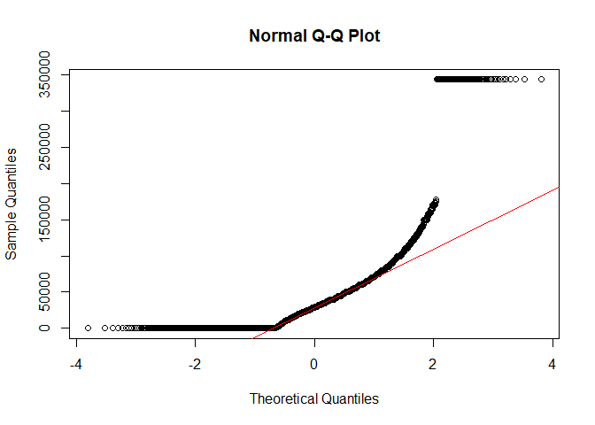

```r
#QQ Plot

with(nlsy, qqnorm(income))
with(nlsy, qqline(income, col = "red"))
```

```r
#Omit topcoded values for income variable
nlsy$income[nlsy$income == 343830] <- NA
```

Once I removed the top 2% earners, the income variable appeared to be as normally distributed as it could be as you can see below in the new QQ plot.

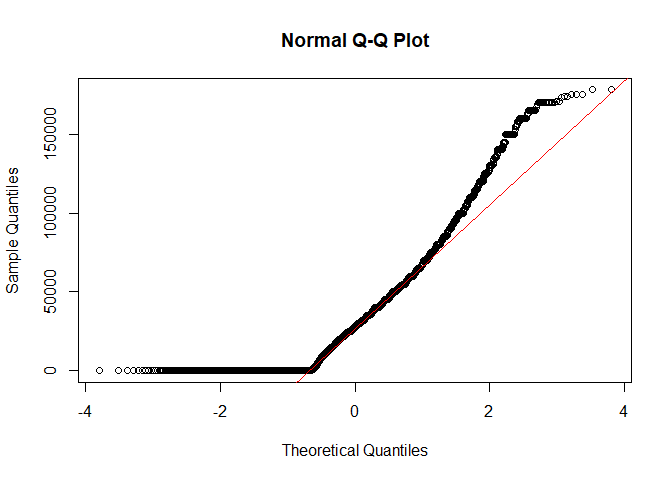

```r
with(nlsy, qqnorm(income))
with(nlsy, qqline(income, col = "red"))
```

*Variables*

I renamed the variables I chose to:

- edu.attmnt
- sex
- race
- forgn.lang
- fam.size
- mar.stat.2000
- pov.stat.1979

I recoded the levels of sex to “Male” and “Female”. For edu.attmnt. I named the years education below 12 as “Less than HS,” 12 years as “HS Grad”, 1st to 3rd year of college as “Some College” and the rest of the levels stayed the same when looking into 4th to 8th year of college or more. Race had three levels so I made Hispanic into Latino, Black into Black and Non-Hispanic and Non-Black to White. Family size was releveled after 4 children as “More than 4” and the number of children below that was left alone. Marital Status was put into “Married”, “Never Married”, “Separated or Divorced” and “Widowed.” Lastly, poverty status was left as “In Poverty” and “Not in Poverty”.

I did remove rows from all of these variables as well. The rows I removed were invalid skips, valid skips or no-interview. Some variables such as mar.stat.2000 and fam.size needed to have the no-interviews removed because not all respondents were interviewed in 2000 for marital status and 2012 for family size.

This does affect the data. However, this does not hinder our ability to observe the income difference between men and women.

These NA’s are removed from all figures but not tables.

*Income Distribution*

Looking at the distribution of income in the survey in Figure 1, we can see that there are more respondents earning less than $10,000, roughly.

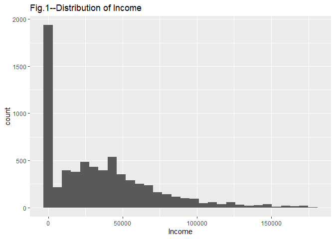

```r
#First look at income distribution for data

#hist
base.plot.income <- ggplot(data = nlsy) +
  geom_histogram(aes(x = income)) +
  xlab("Income") +
  ggtitle("Fig.1--Distribution of Income")
base.plot.income
```

*Average Income*

```r
#Find Average Income
avg.income <- round(mean(nlsy$income, na.rm = TRUE), 2)
avg.income
```

```
## [1] 34844.25
```

```r
#summary table for income and sex
sum.tab.sex <- ddply(nlsy, ~ sex, summarize, avg.income = round(mean(income, na.rm = TRUE), 2))
sum.tab.sex
```

```
##      sex avg.income
## 1 Female   28492.32
## 2   Male   41834.09
```

Figure 2 is a visualization of the income difference between men and women. The average income for males is the black geo_vline and the average income for females is the yellow geo_vline.

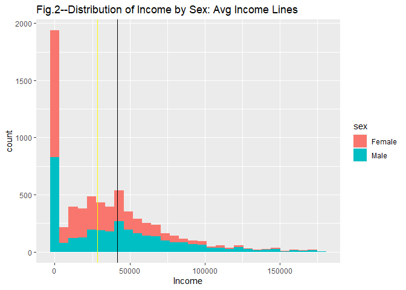

```r
#Overlaid Histogram--Income vs sex
hist.income.sex <- base.plot.income + geom_histogram(aes(x = income, fill = sex)) +
  geom_vline(xintercept = mean(nlsy$income[nlsy$sex == "Male"], na.rm = TRUE), color = "black") +
  geom_vline(xintercept = mean(nlsy$income[nlsy$sex == "Female"], na.rm = TRUE), color = "yellow") +
  ggtitle("Fig.2--Distribution of Income by Sex: Avg Income Lines")
hist.income.sex
```

```r
#Creating new variable--income.avg
nlsy$income.avg <- NA
nlsy$income.avg[nlsy$income > 34844.25] <- "Above average"
nlsy$income.avg[nlsy$income < 34844.25] <- "Below average"
nlsy$income.avg <- as.factor(nlsy$income.avg)
```

**Proportion Plot**

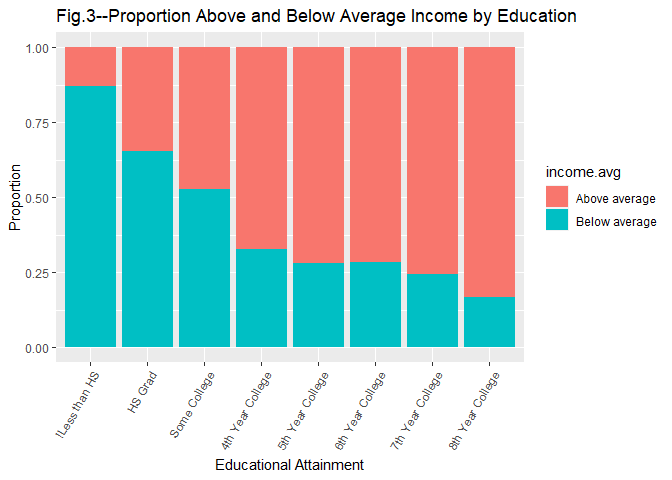

```r
#Proportion plot--education vs income.avg

income.avg.new <- subset(nlsy, !is.na(nlsy$income.avg))

edu.avgincome.plot <- ggplot(income.avg.new, aes(x = edu.attmnt, fill = income.avg)) +
        geom_bar(position = "fill") +
        theme(axis.text.x = element_text(angle = 60, vjust = 1, hjust = 1)) +
        labs(x = "Educational Attainment", y = "Proportion", title = "Fig.3--Proportion Above and Below Average Income by Education")

edu.avgincome.plot
```

*Income Differences*

```r
#Difference in average income by education and sex--table

mean.diff.edu <- ddply(nlsy, ~ edu.attmnt, summarize,
               mean.diff = round(mean(income[sex == "Male"], na.rm = TRUE) -
               mean(income[sex == "Female"], na.rm = TRUE), 2))
mean.diff.edu
```

```
##         edu.attmnt mean.diff
## 1    !Less than HS   9890.57
## 2          HS Grad  12620.20
## 3     Some College  17880.56
## 4 4th Year College  27232.20
## 5 5th Year College  29061.17
## 6 6th Year College  24066.33
## 7 7th Year College   6917.76
## 8 8th Year College  13313.13
## 9             <NA>       NaN
```

Looking at the difference in income between sexes, we can see that men earn more than women at most levels of education. What is interesting is that the income gap between the sexes increases as the year of education increases. The income gap is 9890.57 dollars for those with less than high school completed and that increases to 29061.17 dollars by 5th year college and higher completed. However, The 6th, 7th and 8th year of college completed do not follow this trend.

I will explore the statistical significance of the other variables I chose in the Finding sections.

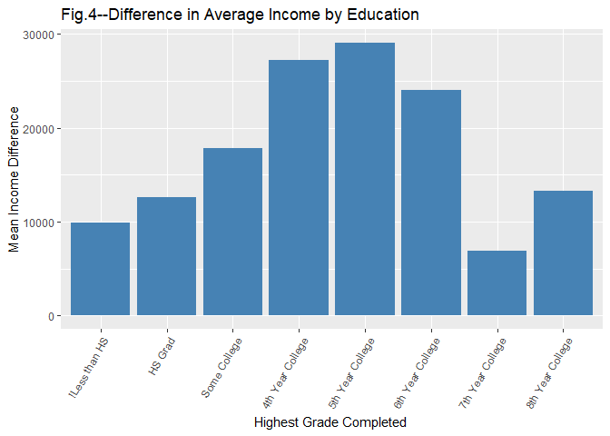

```r
#subset out the NA's from edu
mean.diff.edu.new <- subset(mean.diff.edu, !is.na(mean.diff.edu$edu.attmnt))

#Distribution of average income by edcuation and sex--bar chart
i.s.edu.fig <- ggplot(data = mean.diff.edu.new,
     aes(x = edu.attmnt, y = mean.diff)) +
geom_bar(stat = "identity", fill = "steelblue")+
               theme(axis.text.x = element_text(angle = 60, vjust = 1, hjust = 1))+
               labs(x = "Highest Grade Completed ", y = "Mean Income Difference", title = "Fig.4--Difference in Average Income by Education")
i.s.edu.fig
```

```r
#Difference in average income by race and sex--table

mean.diff.race <- ddply(nlsy, ~ race, summarize,
            mean.diff = mean(income[sex == "Male"], na.rm = TRUE) -
            mean(income[sex == "Female"], na.rm = TRUE),
            lower = t.test(income[sex == "Male"], income[sex == "Female"])$conf.int[1],
            upper = t.test(income[sex == "Male"], income[sex == "Female"])$conf.int[2]
                       )

mean.diff.race
```

```
##     race mean.diff     lower     upper
## 1  Black  5402.628  2841.950  7963.306
## 2 Latino 11124.956  7596.311 14653.601
## 3  White 19558.801 17065.652 22051.950
```

Figure 5 illustrates the income gap by race. The error bars give some preliminary insight into looking at the race as being statistically significant in this project. The average difference between men and women for each race is between the lower and upper confidence intervals for each group so this will lead me to add sex into my linear model.

[figure not shown]

```r
#race--chart
i.s.race.fig <- ggplot(mean.diff.race, aes(x = race, y = mean.diff)) +
  geom_bar(stat = "identity", fill = "steelblue") +
               labs(x = "", y = "Mean Diff of Earning Rates", title = "Fig.5--Difference in High Earning Rates by Employer")+
  geom_errorbar(aes(ymin = lower, ymax = upper),
                width = 0.2,
                size = 1,
                position = position_dodge(0.9),
                color = "red")
i.s.race.fig
```

```r
#Difference in average income by pov.stat and sex--table

mean.diff.pov <- ddply(nlsy, ~ pov.stat.1979, summarize,
            mean.diff = mean(income[sex == "Male"], na.rm = TRUE) -
            mean(income[sex == "Female"], na.rm = TRUE),
            lower = t.test(income[sex == "Male"], income[sex == "Female"])$conf.int[1],
            upper = t.test(income[sex == "Male"], income[sex == "Female"])$conf.int[2]
                       )

mean.diff.pov
```

```
##    pov.stat.1979 mean.diff     lower    upper
## 1     In Poverty  7283.569  4169.904 10397.23
## 2 Not in Poverty 14897.475 12736.161 17058.79
## 3           <NA> 12563.206  8795.910 16330.50
```

Figure 6 visualizes the differences from the table, but it excludes the NA values. The average difference in income between those in poverty and not in poverty appears to be statistically significant since the average difference is between the lower and upper values of the confiednce intervals for the two groups. With the range between upper and lower confidence intervals for these two groups being small as well, I did not investigate them any further.

[figure not shown]

```r
#subset out NA's for poverty
mean.diff.pov.new <- subset(mean.diff.pov, !is.na(mean.diff.pov$pov.stat.1979))

#pov--chart
i.s.pov.fig <- ggplot(mean.diff.pov.new, aes(x = pov.stat.1979, y = mean.diff)) +
  geom_bar(stat = "identity", fill = "steelblue") +
               labs(x = "", y = "Mean Diff of Earning Rates", title = "Fig.6--ifference in High Earning Rates by Employer")+
  geom_errorbar(aes(ymin = lower, ymax = upper),
                width = 0.2,
                size = 1,
                position = position_dodge(0.9),
                color = "red")
i.s.pov.fig
```

*Facet Grids*

When looking into whether or not a foreign language was spoken at home and its relationship with income difference between men and women, I chose to represent that with a face grid visualization.

Doing this is interesting to see the difference visually with the bar chart for those who did not speak a foreign language versus those who did. I did not run a t.test for this variable to see if it is statistically significant, but will include it in a linear model.

Figure 7 shows that the difference in income between men and women is smaller for those who did speak a foreign language at home than for men and women who did not.

I cannot make any conclusions as to why this is, but I there can be multiple confounding factors to this such as citizenship status, generation of immigration, city of residence, education level of the respondent’s parents, and so on.

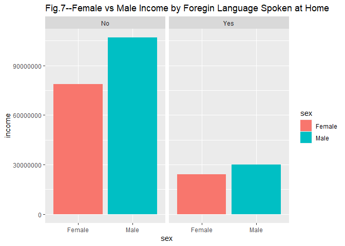

```r
#Facet Grids

fg.foreign <- ggplot(subset(nlsy, forgn.lang %in% c("No", "Yes")), aes(x = sex, y = income, fill=sex)) + geom_bar(stat = "identity") + facet_grid(.~forgn.lang) +  ggtitle("Fig.7--Female vs Male Income by Foregin Language Spoken at Home")
fg.foreign
```

I was not able to run a t.test on marital status because it has more than two levels, so a facet grid displaying the income gap between those are married, separated or divorced, never married and widowed can be seen in Figure 8. In this data set, it is interesting that female widows appear to report a slightly higher income than widowed males. Females also appear to report higher income than males for those who are separated or divoreced which I also find interesting. The gap between males and females who were never married is smaller than those who are married.

All of these findings can might have confouding factors such as people who have never been married might work in sectors that would make the sex income gap smaller, or those who are separated or divorced in this data set, might be in sectors that have lower income to starts with. I would not use this facet grid to make conclusions about a population.

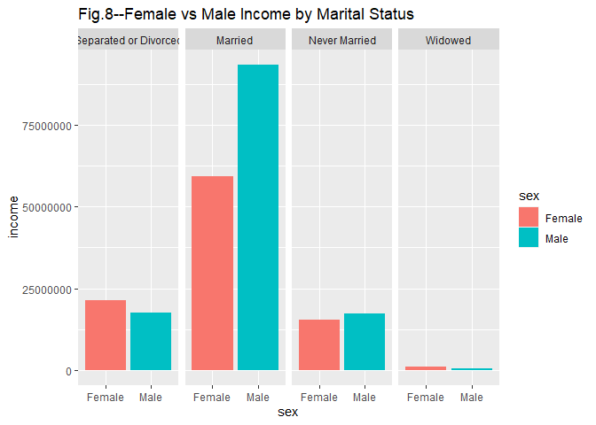

```r
fg.martial <-
  ggplot(subset(nlsy, mar.stat.2000 %in% c("Never Married", "Married", "Separated or Divorced", "Widowed")), aes(x = sex, y = income, fill=sex)) + geom_bar(stat = "identity") + facet_grid(.~mar.stat.2000) +
  ggtitle("Fig.8--Female vs Male Income by Marital Status")
fg.martial
```

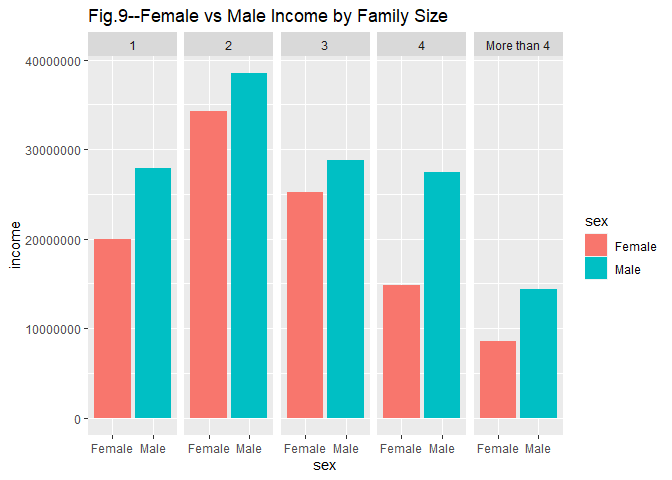

```r
fg.family <- ggplot(subset(nlsy, fam.size %in% c("1", "2", "3", "4", "More than 4")), aes(x = sex, y = income, fill=sex)) + geom_bar(stat = "identity") + facet_grid(.~fam.size) +
  ggtitle("Fig.9--Female vs Male Income by Family Size")
fg.family
```

*Linear Models*

```r
#Linear Model
relevelToMostFrequent <- function(x) {
  if (is.factor(x)) {
    # Determine most frequent category
    most.freq.level <- levels(x)[which.max(table(x))]
    # Relevel to set most frequent category as the baseline
    relevel(x, ref = most.freq.level)
  } else {
    x
  }
}
# Re-level the data
nlsy <- as.data.frame(lapply(nlsy, FUN = relevelToMostFrequent))
sapply(nlsy, function(x){ifelse(is.factor(x), levels(x)[1], NA)})
```

```
##       forgn.lang             race              sex    pov.stat.1979
##             "No"          "White"           "Male" "Not in Poverty"
##    mar.stat.2000           income         fam.size       edu.attmnt
##        "Married"               NA              "2"        "HS Grad"
##          edu.new       income.avg
##               NA  "Below average"
```

```r
overall.pract.lm <- lm(income ~ sex + edu.attmnt + race + pov.stat.1979 + mar.stat.2000 + forgn.lang + fam.size, data = nlsy)

sum.overall.pract.lm <- summary(overall.pract.lm)

#Make it look pretty
kable(sum.overall.pract.lm$coef)
```

|  | Estimate | Std. Error | t value | Pr(>\|t\|) |
| --- | --- | --- | --- | --- |
| (Intercept) | 43369.37137 | 1141.1172 | 38.0060613 | 0.0000000 |
| sexFemale | -17067.51626 | 863.5547 | -19.7642552 | 0.0000000 |
| edu.attmnt!Less than HS | -12750.39079 | 1568.7564 | -8.1277059 | 0.0000000 |
| edu.attmntSome College | 9346.99132 | 1064.5826 | 8.7799584 | 0.0000000 |
| edu.attmnt4th Year College | 26948.75034 | 1417.9775 | 19.0050615 | 0.0000000 |
| edu.attmnt5th Year College | 30090.01245 | 2481.8038 | 12.1242511 | 0.0000000 |
| edu.attmnt6th Year College | 34519.30214 | 2271.7877 | 15.1947748 | 0.0000000 |
| edu.attmnt7th Year College | 37460.89846 | 3342.8911 | 11.2061380 | 0.0000000 |
| edu.attmnt8th Year College | 51043.45187 | 3283.6659 | 15.5446547 | 0.0000000 |
| raceBlack | -5774.59430 | 1079.3198 | -5.3502161 | 0.0000001 |
| raceLatino | -464.59761 | 1784.1370 | -0.2604047 | 0.7945621 |
| pov.stat.1979In Poverty | -6726.24231 | 1084.6614 | -6.2012368 | 0.0000000 |
| mar.stat.2000Separated or Divorced | -4129.10694 | 1160.1516 | -3.5591099 | 0.0003755 |
| mar.stat.2000Never Married | -8164.67543 | 1212.5571 | -6.7334358 | 0.0000000 |
| mar.stat.2000Widowed | -2314.28495 | 4455.0391 | -0.5194758 | 0.6034513 |
| forgn.langYes | 148.74241 | 1643.8303 | 0.0904853 | 0.9279051 |
| fam.size1 | -3727.89893 | 1216.0468 | -3.0655883 | 0.0021837 |
| fam.size3 | -50.72479 | 1201.0509 | -0.0422337 | 0.9663141 |
| fam.size4 | 1567.17280 | 1350.1505 | 1.1607394 | 0.2458017 |
| fam.sizeMore than 4 | -2315.12082 | 1565.5810 | -1.4787614 | 0.1392653 |

I ran a preliminary linear model to see which variables were not statiscally significant. I was not able to run t-tests on all variables so I used the p-values in the summeary of the linear model to make conclusions about statistical significance.

Since I looked at confidence intervals for race, I will keep that variable even though the coefficient for a male Latino is not statistically significant at 0.79.After looking at my baselines, I made the decision to only include variables that have a p-value of 0 in my coefficients chart. I wanted to ensure that my variables were going to be significant at the 0.05 level. Therefore I did not include, martial status, family size, or whether a foreign language was spoken in the home in the linear model I will interpret next.

```r
#Better lm
overall.lm <- lm(income ~ sex + edu.attmnt + race + pov.stat.1979, data = nlsy)

sum.overall.lm <- summary(overall.lm)


#Make it look pretty
kable(sum.overall.lm$coef)
```

|  | Estimate | Std. Error | t value | Pr(>\|t\|) |
| --- | --- | --- | --- | --- |
| (Intercept) | 39759.297 | 862.7124 | 46.086388 | 0.0000000 |
| sexFemale | -16012.019 | 832.8619 | -19.225298 | 0.0000000 |
| edu.attmnt!Less than HS | -13841.698 | 1508.0612 | -9.178472 | 0.0000000 |
| edu.attmntSome College | 9962.627 | 1038.8846 | 9.589733 | 0.0000000 |
| edu.attmnt4th Year College | 27971.890 | 1374.3663 | 20.352572 | 0.0000000 |
| edu.attmnt5th Year College | 30606.572 | 2478.6232 | 12.348214 | 0.0000000 |
| edu.attmnt6th Year College | 33868.892 | 2196.7788 | 15.417525 | 0.0000000 |
| edu.attmnt7th Year College | 38690.501 | 3336.0076 | 11.597846 | 0.0000000 |
| edu.attmnt8th Year College | 53330.816 | 3211.1943 | 16.607782 | 0.0000000 |
| raceBlack | -8188.650 | 1009.2403 | -8.113677 | 0.0000000 |
| raceLatino | -1171.412 | 1136.7540 | -1.030489 | 0.3028254 |
| pov.stat.1979In Poverty | -6796.523 | 1047.2491 | -6.489882 | 0.0000000 |

My baseline for this linear model is, holding all else constant, a white male who completed 12th grade (HS), and who was not in poverty at the age of 14 to 22 in 1979. That person has an average income of $39,759.29. Starting from there I am able to look at other coefficients and what they show about the income gap.

Whites males who finished high schools but were in poverty, have an average income of $32,962.77.

White females who finished high school and were not in poverty have an average income of 23,747.27 dollars. For a white female who finished high school but was in poverty, their average income is 16,950.75 dollars.

Black males who finished high school and were not in poverty, have an average income of $31,570.64. For black females with those same characteristics, their average income is 15,558.62 dollars.

I am interested in observing these same characteristics for those who have completed a 4th year of college and were in poverty.

White males who completed the 4th year of college and were in poverty had an average income of 60,934 dollars. White females with the same characteristics had an average income of 44,922 dollars.

Black males who completed the 4th year of college and were in poverty had an average income of 52,746 dollars. Black females with the same characteristics had an average income of 36,734 dollars.

*Diagnostic Plots*

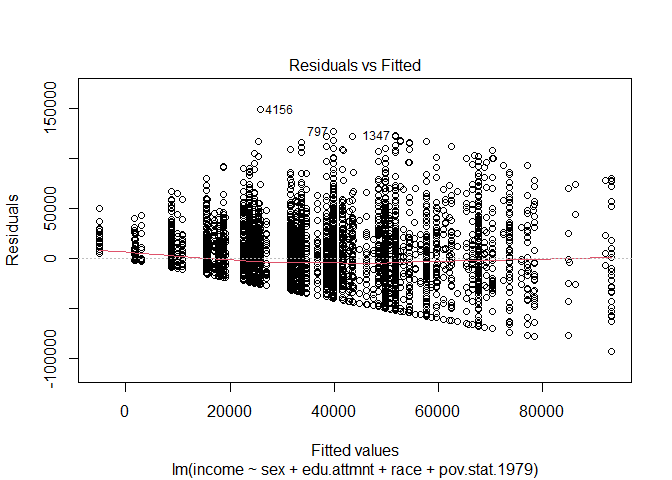

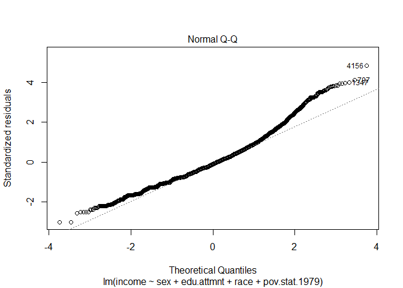

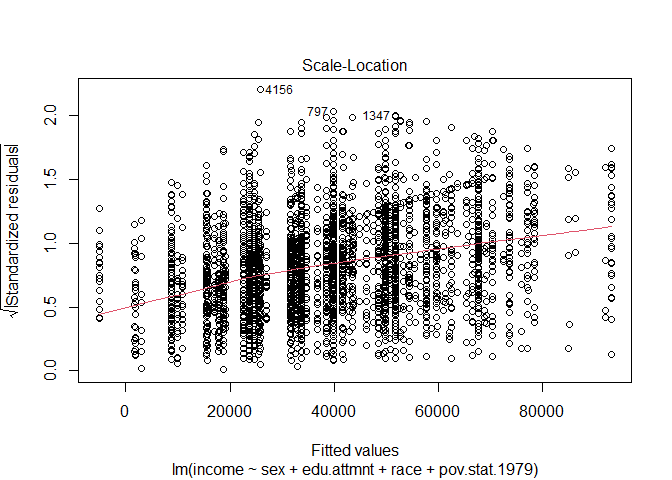

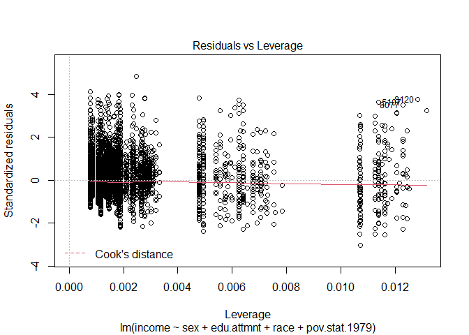

```r
plot(overall.lm)
```

Looking at the plots from my linear model, I am able to see that my model can be said to have a linear-relationship. From the Residuals vs Fitted plot we see that there is almost a fan shape. This violates the assumption that there is constant variance in my model. My model can be used to explain there is, on average, an income gap between men and women, but I cannot say that is true always with the lack of confidence in constant variance. I would need to look at the scale-location plot to confirm.

The Scale-location plot does show that there is not constant variance for every variable in my linear model. It looks better than I had hoped, but there is still not constant variance across the board.

The Residual versus Leverage helps me see if there are any influential outliers. I see two outliers with numbers that appear to be 120 and 510. These outliers are not past Cook’s distance so I can conclude that these outliers are not influential.

**Scatterplot**

After looking at the coefficients of my liner model, I wanted to investigate further into one of the variables and I chose poverty. A few plots were made, and I found the plot in Figure 10 the most interestng.

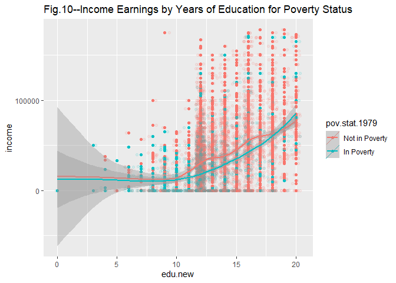

```r
#Poverty plot

intercepts <- c(coef(overall.lm)["(Intercept)"],
                coef(overall.lm)["(Intercept)"] + coef(overall.lm)["pov.stat.1979In Poverty"])

lines.df <- data.frame(intercepts = intercepts,
                       slopes = rep(coef(overall.lm)["income"], 2),
                       poverty = levels(nlsy$pov.stat.1979))

poverty.geom.plot <- ggplot(subset(nlsy, pov.stat.1979 %in% c("Not in Poverty", "In Poverty")),  aes(x = edu.new, y = income, color = pov.stat.1979)) +
  geom_point() +
  geom_abline(aes(intercept = intercepts,
                  slope = slopes,
                  color = poverty), data = lines.df) +
  geom_jitter(alpha = 0.1) +
  geom_smooth(fullrange = TRUE) +
  ggtitle("Fig.10--Income Earnings by Years of Education for Poverty Status")

poverty.geom.plot
```

*Methodolgy*

**Missing Values**

As discussed prior, I removed NA’s from my data set. I made the top 2% of earners in the income variable NA’s to get a better picture of average income for the average person.

The NA’S for my other variables were created because they were simply missing values. They were removed from my bar charts but not from my tables.

**Tables, Charts, Findings**

Throughout this project, I attempted many charts and charts. Some of the things I chose not to add can be seen in my Rmd file.

After running extra tables and charts, the relationship I chose to not leave out is the one in Figure 10. I’m sure if I explored multiple variables in the data set I would have more interesting findings. Anything that was not already discussed to some extent in my findings was omitted and can be seen on my Rmd file.

*Discussion*

**Conclusions** Considering the size of the data set and that it is a longitudinal survey that is supposed to be representative of the population, I can conclude that there is an income gap between men and women. This income gap also spreads to other areas such as poverty status during youth, race, education attainment and so on.

With the variables I selected, I do not believe that there are many confounding variables. I believe that individual idiosyncrasies were controlled for when the survey was conducted.